# WHITE_WINE_QUALITY by JOLENE YAO

# Multivariate Analysis

### Talk about some of the relationships you observed in this part of the investigation. Were there features that strengthened each other in terms of looking at your feature(s) of interest?

I chose the two variables density and alcohol because density is heavily affected by alcohol. Alcohol has a low density and it makes sense that with a greater alcohol content, quality of the wine will increase; the teal colors of higher wine quality is at the lower right-hand corner of the plot. Other variables that affect density is free sulfur dioxide, total sulfur dioxide and sulphates which means that more of these will increase density slightly and increase quality. However, I did not include these in my plots since I did not want to confuse the readers of this project. A lower density of white wine should generally be higher quality wine. Though, not all dense additives to wine will increase quality. Sometimes these additivies will increase density while increasing quality.

### Were there any interesting or surprising interactions between features?

Like I stated above, some aspects of the wine will increase and decrease density. Generally, a lower density wine will have a higher quality.

### OPTIONAL: Did you create any models with your dataset? Discuss the strengths and limitations of your model.

I created a linear regression model using the variables free sulfur dioxide, alcohol, and density. It showed that the r^2 came out to be 0.21 which means that the three variables accounts for 21% of the quality of white wines. There are a lot more other variables that account for the quality of white wines.

# Final Plots and Summary

### Plot One

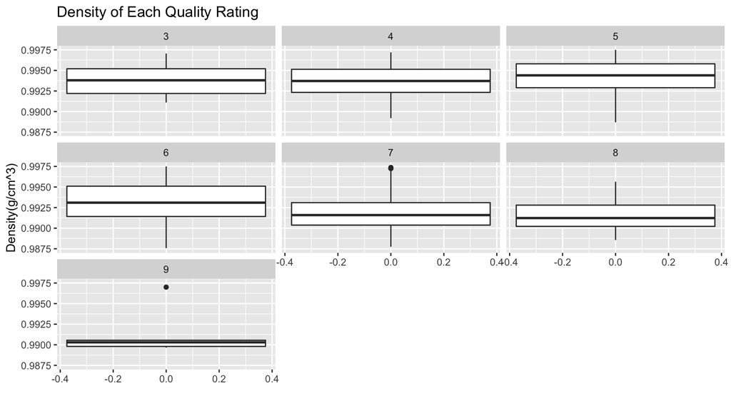

### Description One

These boxplots show that there is a decrease in density as quality of white wine increases. With a 3 quality rating, the density reaches 0.9950g/cm^3. With a 9 quality rating, it is just above 0.9900g/cm^3.